# Primas Mapfre

José María Álvarez Silva

Predicción

# Propósito

Predicción del número de primas total, vida y no vida por separado para después sumar y comparar. Realizar un análisis para seleccionar el mejor modelo (capacidad predictiva) con el cual se realizará la predicción.

# Predicción

Se llevo a cabo la predicción de las primas de Mapfre para los trimestres de los próximos dos años. La predicción:

|  | Q1 | Q2 | Q3 | Q4 |
| --- | --- | --- | --- | --- |
| 2018 | 6431.081 | 6070.836 | 5516.262 | 5619.637 |
| 2019 | 6484.425 | 6120.941 | 5563.325 | 5663.844 |

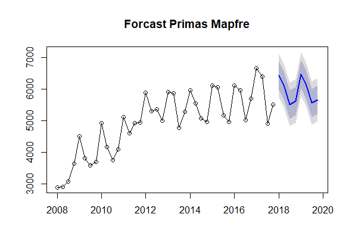

El modelo utilizado fue un modelo ETS sobre el total de primas de Mapfre.

# Resumen Ejecutivo

## Proceso General

En este análisis utilizamos dos enfoques para la predicción de las primas de los seguros vendidos por Mapfre. Se trabajó primero con el total de primas (sin distinguir por tipo de producto) y, por otro lado, distinguiendo entre primas de seguros de vida y seguros de no vida. Los enfoques utilizados para predicir:

- Exponential Smoothing (Ets - Error, Trend and Season).
- ARIMA.

## Resultados

Comparando el poder predictivo de cada uno de los modelos (generados con el set de entrenamiento) a través de la métricas de error de predicción (MSE, MAE y Bias) en el set de Test (primas vendidas por trimestre en el año 2017), el modelo que tuvo mejor desempeño fue el ETS para el total de primas vendidas (i.e. sin distinción de productos). Como se muestra en la tabla a continuación:

[output not shown]

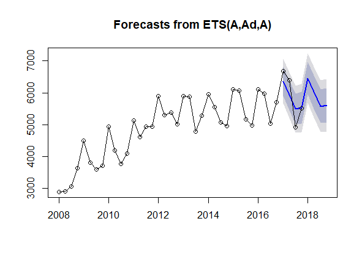

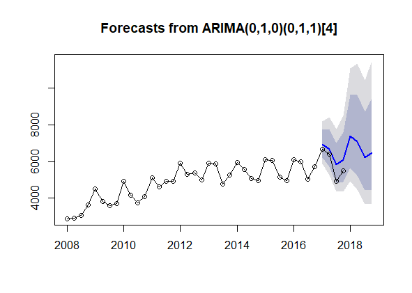

Comparando el poder predictivo para el producto de seguros de Vida. El modelo ARIMA es el que moejor poder predictivo tiene.

|  | MSE | MAE | Bias |
| --- | --- | --- | --- |
| Vida ETS | 25336.91 | 151.6686 | -47.48728 |
| Vida ARIMA | 21651.86 | 112.5497 | -44.29429 |

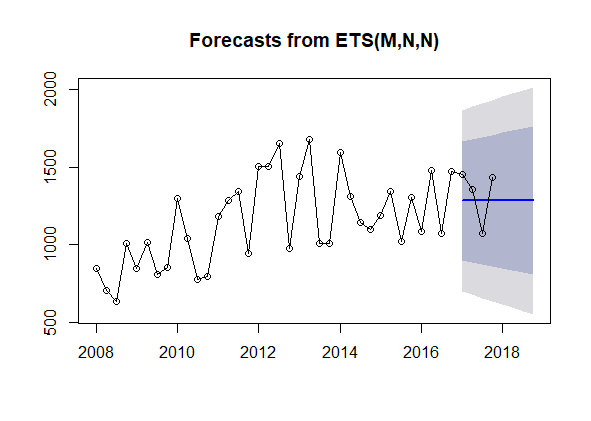

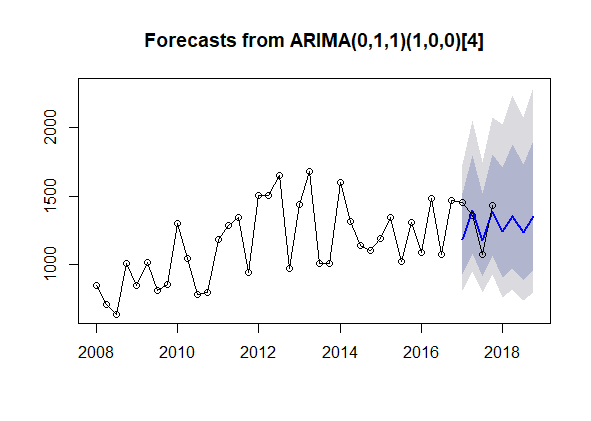

El modelo ARIMA parece explicar mejor la componente estacional de los seguros de vida. El gráfico del modelo ETS devuelve una prediccion plana para este tipo de seguro.

[output not shown]

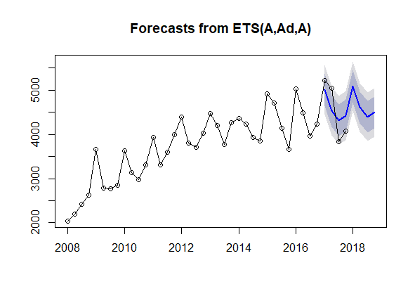

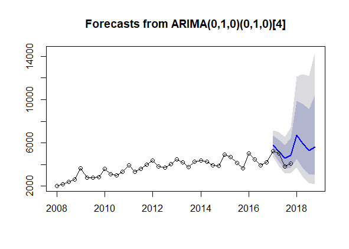

## Predicción 2018 y 2019

Al ser el mejor modelo en Test el ETS del total, se llevo a cabo la predicción para los trimestres de los próximos dos años de las primas totales de Mapfre. La predicción:

|  | Q1 | Q2 | Q3 | Q4 |
| --- | --- | --- | --- | --- |
| 2018 | 6431.081 | 6070.836 | 5516.262 | 5619.637 |
| 2019 | 6484.425 | 6120.941 | 5563.325 | 5663.844 |

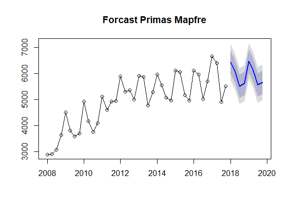

## Observaciones

Basados en las comparativas de métricas de errores de prediccón se ha mostrado cual sería la predicción para los próximos dos años según el mejor modelos. Algo que resulta interesante es que para total y no vida, el mejor modelo era ETS en ambos casos. Sin embargo, el mejor modelo para predecir las primas de vida es un modelo ARIMA (se ha dado una explicación del porque creemos que sucede esto).

## Comparación de predicciones de los modelos por tipo de producto

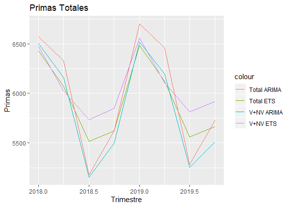

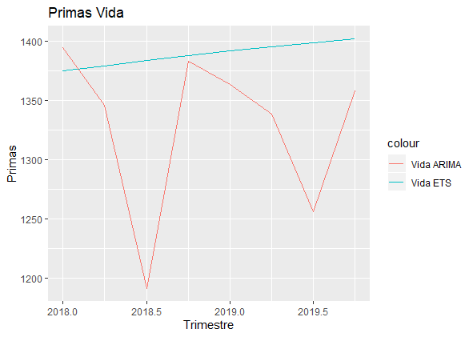

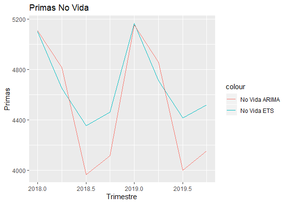

# Anexos y Código

## Paquetes y Datos

```r
## Paquetes ############################################################################################
##
library(dplyr)
library(tidyverse)
require(forecast)
require(xts)
```

```r
require(ggplot2)
library(zoo)
library(hts)
library(ggfortify)
## Datos ###############################################################################################
##
datos <- read.csv("Primas_mapfre.csv", sep = ";", dec = ",")
## Total
datos <- datos %>% mutate(total = Primas_vida + Primas_no_vida)
## Fecha
datos$Fecha <- as.Date(datos$Fecha, "%m/%d/%Y")
```

## Análisi Exploratorio de Datos

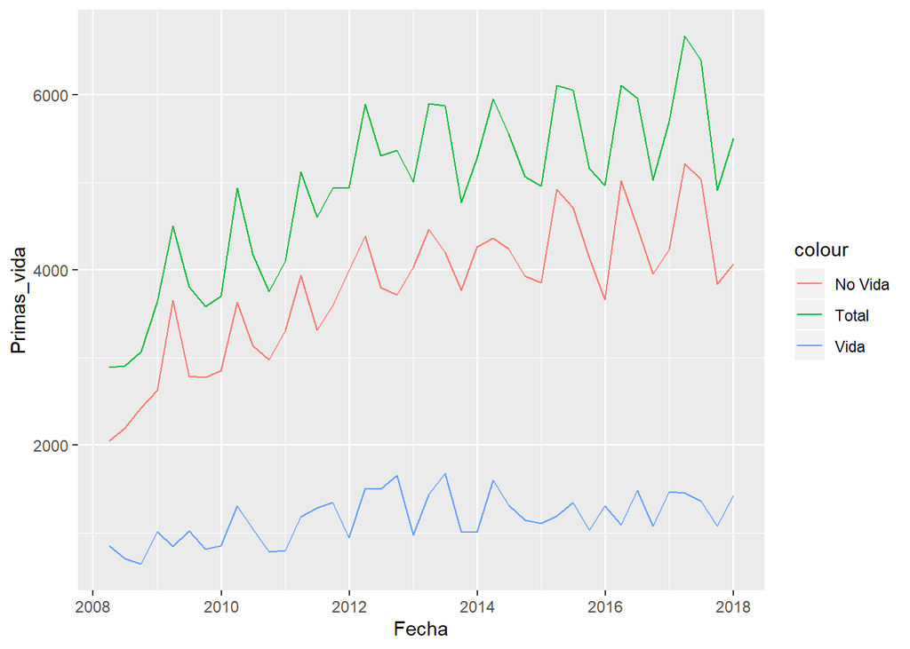

```r
## Análisis exploratorio de datos ######################################################################
##
ggplot(data = datos, aes(x = Fecha)) +
  geom_line(aes(y = Primas_vida, colour = "Vida")) +
  geom_line(aes(y = Primas_no_vida, colour = "No Vida")) +
  geom_line(aes(y = total, colour = "Total"))
```

## Modelo ETS para primas totales

### Preparando datos

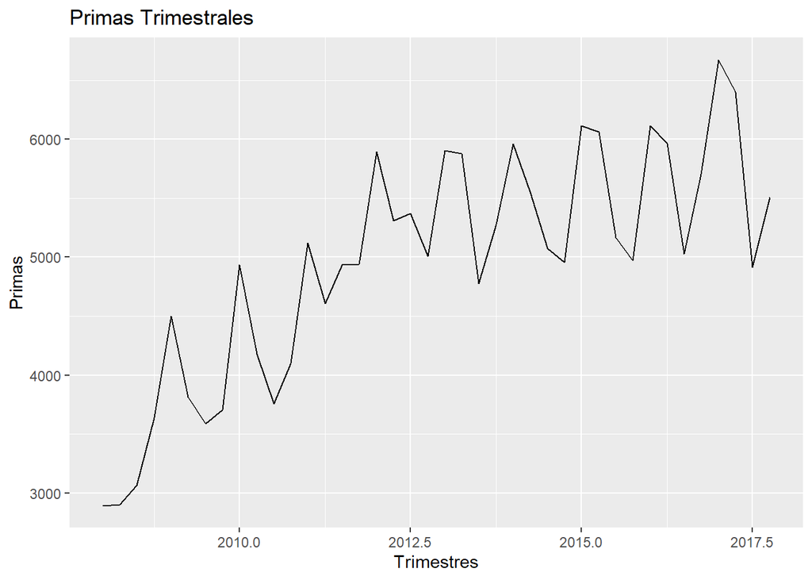

```r
## Trabajando un modelo ETS para Total #################################################################
##

## Plot Serie Total
total = xts((datos$total), order.by = datos$Fecha, frequency = 4)
## Generate quarterly data
total = to.quarterly(total)  ## OJO cambia a que sea trimestral
## paqueteria zoo para mejor funcionamiento
total = as.zoo(total$total.Close)
autoplot(total) + ggtitle("Primas Trimestrales") + xlab("Trimestres") + ylab("Primas")
```

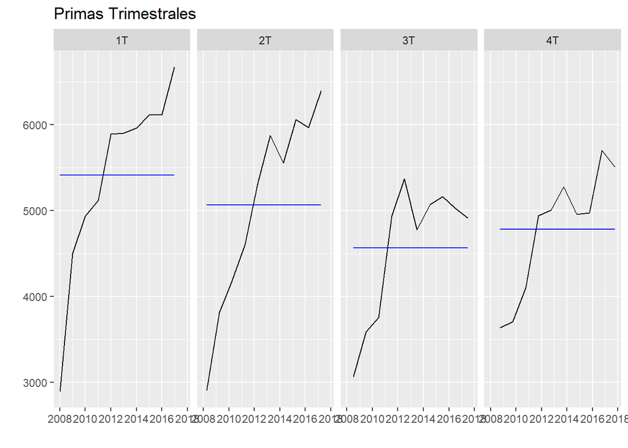

```r
## Seasonal Plot
ggfreqplot(as.ts(total), freq = 4, nrow = 1, facet.labeller = c("1T","2T","3T","4T")) +
  ggtitle("Primas Trimestrales")
```

### Trainig set

```r
#- Training set     -#-#-#-#-#-#-#-#-#-#-#-#-#-#-#-#-#-#-#-#-#-#-#-#-#-#-#-#-#-#-#-#-#-#-#-#-#-#-#-#

## Select number of observation to compare forecast
cOmit = 4

## Data Size
nObs = length(total)

## sub_sample
oTotal <- window(total,start = index(total[1]),end = index(total[nObs - cOmit]))
```

### Test

```r
Totaletsfit <- ets(oTotal)
#f orecast model
fTotal.ets = forecast(Totaletsfit)
# Results
summary(fTotal.ets)
```

```
##
## Forecast method: ETS(A,Ad,A)
##
## Model Information:
## ETS(A,Ad,A)
##
## Call:
##  ets(y = oTotal)
##
##   Smoothing parameters:
##     alpha = 0.2424
##     beta  = 1e-04
##     gamma = 1e-04
##     phi   = 0.9505
##
##   Initial states:
##     l = 2931.1472
##     b = 178.7185
##     s = -335.3013 -349.5291 114.6065 570.2239
##
##   sigma:  356.3793
##
##      AIC     AICc      BIC
## 561.7218 570.5218 577.5570
##
## Error measures:
##                     ME     RMSE      MAE        MPE     MAPE      MASE
## Training set -5.403611 308.6335 249.7589 -0.4948873 5.595178 0.6033052
##                   ACF1
## Training set 0.1276507
##
## Forecasts:
##         Point Forecast    Lo 80    Hi 80    Lo 95    Hi 95
## 2017 Q1       6360.067 5903.349 6816.786 5661.577 7058.558
## 2017 Q2       5930.371 5460.419 6400.324 5211.641 6649.102
## 2017 Q3       5490.845 5008.011 5973.679 4752.414 6229.275
## 2017 Q4       5528.540 5033.151 6023.929 4770.908 6286.172
## 2018 Q1       6456.184 5948.533 6963.836 5679.798 7232.570
## 2018 Q2       6021.727 5502.104 6541.349 5227.033 6816.421
## 2018 Q3       5577.675 5046.343 6109.006 4765.074 6390.276
## 2018 Q4       5611.068 5068.274 6153.862 4780.937 6441.200
```

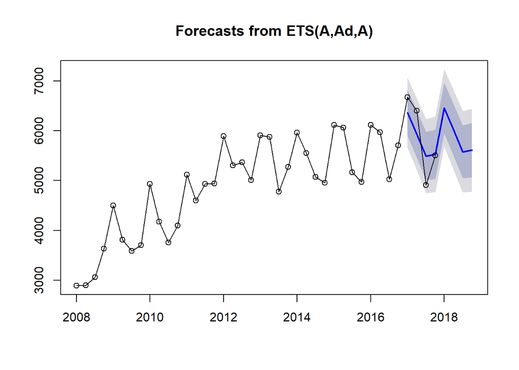

```r
## Eligio un MAM
## - M - multiplicativa la tendencia
## - A - aditiva en la pendiente
## - M - multiplicativa en estacionalidad

## ojo -> simpre que se hagan predicciones se debe dar un intervalo de confianza

# Plot
plot(fTotal.ets)
lines(window(total),type = "o")
```

### Metricas de predicción

```r
#Actual and Forecast
totalFitmat <- matrix(c(fTotal.ets$mean[1:cOmit],total[(nObs - cOmit + 1):nObs]),ncol = 2)
totalFitmat
```

```
##          [,1]   [,2]
## [1,] 6360.067 6674.6
## [2,] 5930.371 6398.6
## [3,] 5490.845 4913.4
## [4,] 5528.540 5507.2
```

```r
## MSE
mean((totalFitmat[,1] - totalFitmat[,2])^2)
```

```
## [1] 163016.7
```

```r
## MAE
mean(abs(totalFitmat[,1] - totalFitmat[,2]))
```

```
## [1] 345.3866
```

```r
## Bias
mean(totalFitmat[,1] - totalFitmat[,2])
```

```
## [1] -45.9941
```

### Predicción

```r
#- Complete set        -#-#-#-#-#-#-#-#-#-#-#-#-#-#-#-#-#-#-#-#-#-#-#-#-#-#-#-#-#-#-#-#-#-#-#-#-#-#-#-#

## Select automatic ETS
etsfit <- ets(total)
## forecast model
total.ets <- forecast(etsfit)
## Results
summary(total.ets)
```

```
##
## Forecast method: ETS(A,Ad,A)
##
## Model Information:
## ETS(A,Ad,A)
##
## Call:
##  ets(y = total)
##
##   Smoothing parameters:
##     alpha = 0.0023
##     beta  = 0.0023
##     gamma = 1e-04
##     phi   = 0.9393
##
##   Initial states:
##     l = 2909.4154
##     b = 210.9936
##     s = -310.0402 -400.4518 167.846 542.646
##
##   sigma:  350.3869
##
##      AIC     AICc      BIC
## 626.0825 633.6687 642.9713
##
## Error measures:
##                    ME     RMSE      MAE       MPE     MAPE      MASE
## Training set -30.1137 308.4599 252.1897 -1.409148 5.580647 0.6237988
##                   ACF1
## Training set 0.2312009
##
## Forecasts:
##         Point Forecast    Lo 80    Hi 80    Lo 95    Hi 95
## 2018 Q1       6431.081 5982.042 6880.120 5744.335 7117.827
## 2018 Q2       6070.836 5621.793 6519.879 5384.084 6757.588
## 2018 Q3       5516.262 5067.210 5965.314 4829.496 6203.028
## 2018 Q4       5619.637 5170.570 6068.705 4932.848 6306.427
## 2019 Q1       6484.425 6035.334 6933.515 5797.600 7171.249
## 2019 Q2       6120.941 5671.820 6570.062 5434.070 6807.813
## 2019 Q3       5563.325 5114.165 6012.485 4876.394 6250.256
## 2019 Q4       5663.844 5214.635 6113.052 4976.839 6350.848
```

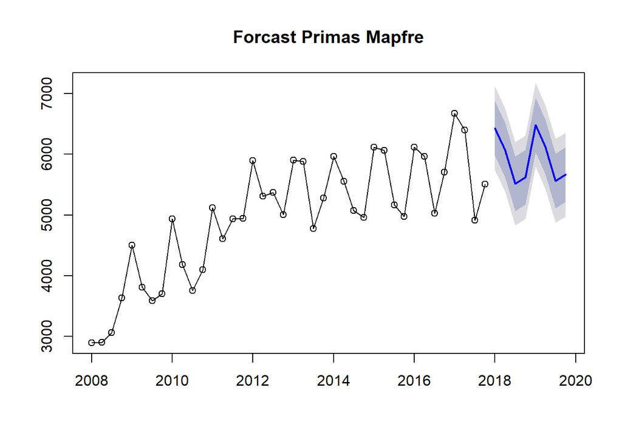

```r
## Eligio un MAM
## - M - multiplicativa la tendencia
## - A - aditiva en la pendiente
## - M - multiplicativa en estacionalidad

## ojo -> simpre que se hagan predicciones se debe dar un intervalo de confianza

# Plot
plot(total.ets, main = "Forcast Primas Mapfre")
lines(window(total),type = "o")
```

## Modelo ETS para primas vida

### Preparando datos

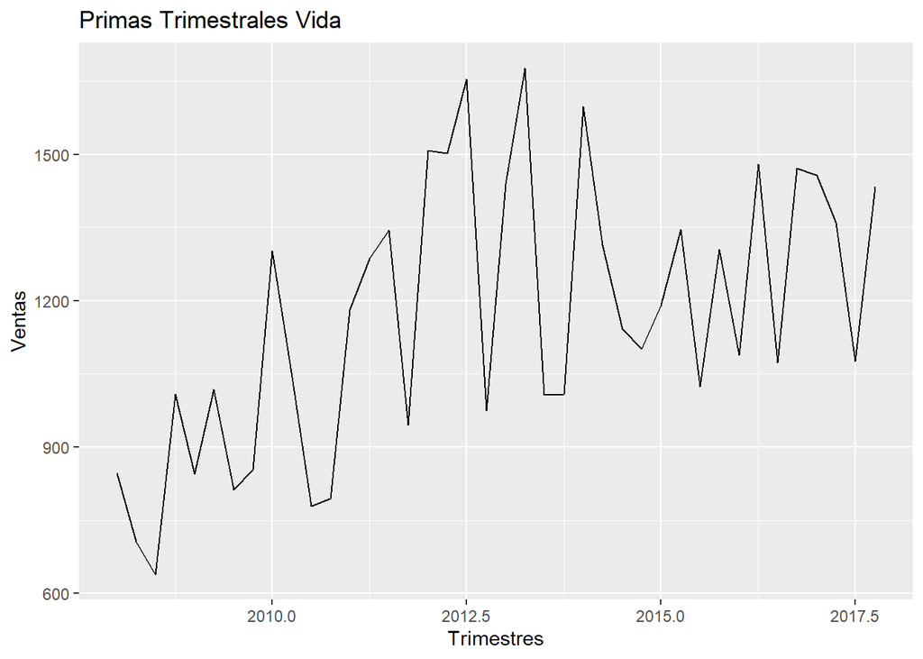

```r
## Trabajando un modelo ETS por separado ###############################################################
##

## Plot Serie Primas Vida
vida = xts((datos$Primas_vida), order.by = datos$Fecha, frequency = 4)
## Generate quarterly data
vida = to.quarterly(vida)  ## OJO cambia a que sea trimestral
## paqueteria zoo para mejor funcionamiento
vida = as.zoo(vida$vida.Close)
autoplot(vida) + ggtitle("Primas Trimestrales Vida") + xlab("Trimestres") + ylab("Ventas")
```

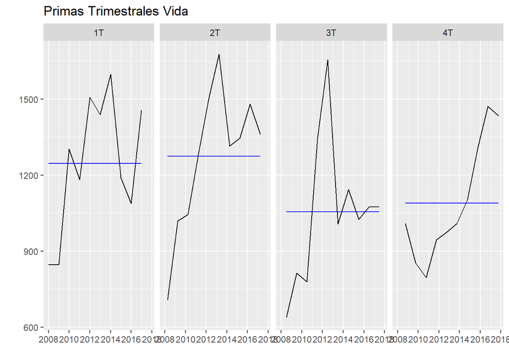

```r
## Seasonal Plot
ggfreqplot(as.ts(vida), freq = 4, nrow = 1, facet.labeller = c("1T","2T","3T","4T")) +
  ggtitle("Primas Trimestrales Vida")
```

### Trainig set

```r
#- Training set     -#-#-#-#-#-#-#-#-#-#-#-#-#-#-#-#-#-#-#-#-#-#-#-#-#-#-#-#-#-#-#-#-#-#-#-#-#-#-#-#

## Select number of observation to compare forecast
cOmit = 4

## Data Size
nObs = length(vida)

## sub_sample
ovida <- window(vida,start = index(vida[1]),end = index(vida[nObs - cOmit]))
```

### Test

```r
vidaetsfit <- ets(ovida)
#f orecast model
fvida.ets = forecast(vidaetsfit)
# Results
summary(fvida.ets)
```

```
##
## Forecast method: ETS(M,N,N)
##
## Model Information:
## ETS(M,N,N)
##
## Call:
##  ets(y = ovida)
##
##   Smoothing parameters:
##     alpha = 0.2755
##
##   Initial states:
##     l = 815.9
##
##   sigma:  0.2314
##
##      AIC     AICc      BIC
## 530.5641 531.3141 535.3147
##
## Error measures:
##                    ME     RMSE      MAE       MPE     MAPE     MASE
## Training set 47.20866 246.8192 212.6659 0.7133133 18.32793 1.121323
##                    ACF1
## Training set -0.1436506
##
## Forecasts:
##         Point Forecast    Lo 80    Hi 80    Lo 95    Hi 95
## 2017 Q1       1284.063 903.3433 1664.782 701.8026 1866.323
## 2017 Q2       1284.063 888.4176 1679.708 678.9757 1889.150
## 2017 Q3       1284.063 873.9775 1694.148 656.8915 1911.234
## 2017 Q4       1284.063 859.9731 1708.152 635.4736 1932.652
## 2018 Q1       1284.063 846.3624 1721.763 614.6578 1953.468
## 2018 Q2       1284.063 833.1095 1735.016 594.3893 1973.736
## 2018 Q3       1284.063 820.1836 1747.942 574.6208 1993.505
## 2018 Q4       1284.063 807.5578 1760.568 555.3114 2012.814
```

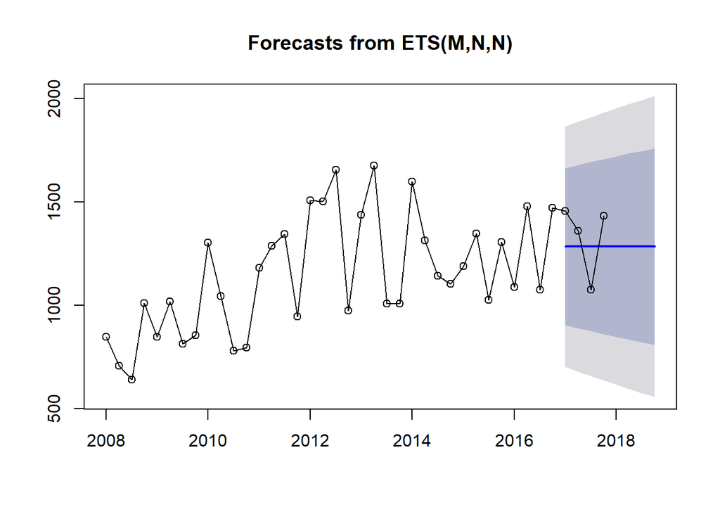

```r
## Eligio un MAM
## - M - multiplicativa la tendencia
## - A - aditiva en la pendiente
## - M - multiplicativa en estacionalidad

## ojo -> simpre que se hagan predicciones se debe dar un intervalo de confianza

# Plot
plot(fvida.ets)
lines(window(vida),type = "o")
```

### Métrica de predicción

```r
#Actual and Forecast
vidaFitmat <- matrix(c(fvida.ets$mean[1:cOmit],vida[(nObs - cOmit + 1):nObs]),ncol = 2)
vidaFitmat
```

```
##          [,1]   [,2]
## [1,] 1284.063 1456.7
## [2,] 1284.063 1360.4
## [3,] 1284.063 1075.7
## [4,] 1284.063 1433.4
```

```r
## MSE
mean((vidaFitmat[,1] - vidaFitmat[,2])^2)
```

```
## [1] 25336.91
```

```r
## MAE
mean(abs(vidaFitmat[,1] - vidaFitmat[,2]))
```

```
## [1] 151.6686
```

```r
## BIAS
mean((vidaFitmat[,1] - vidaFitmat[,2]))
```

```
## [1] -47.48728
```

### Predicción

```r
#- Complete set        -#-#-#-#-#-#-#-#-#-#-#-#-#-#-#-#-#-#-#-#-#-#-#-#-#-#-#-#-#-#-#-#-#-#-#-#-#-#-#-#

## Select automatic ETS
etsfit <- ets(vida)
## forecast model
vida.ets <- forecast(etsfit)
## Results
summary(vida.ets)
```

```
##
## Forecast method: ETS(M,Ad,N)
##
## Model Information:
## ETS(M,Ad,N)
##
## Call:
##  ets(y = vida)
##
##   Smoothing parameters:
##     alpha = 1e-04
##     beta  = 1e-04
##     phi   = 0.9488
##
##   Initial states:
##     l = 691.9139
##     b = 41.6224
##
##   sigma:  0.2025
##
##      AIC     AICc      BIC
## 589.1138 591.6593 599.2471
##
## Error measures:
##                    ME    RMSE      MAE       MPE     MAPE     MASE
## Training set 16.04757 218.207 185.0561 -1.754454 16.14654 1.009871
##                     ACF1
## Training set -0.02219114
##
## Forecasts:
##         Point Forecast    Lo 80    Hi 80    Lo 95    Hi 95
## 2018 Q1       1374.896 1018.090 1731.702 829.2089 1920.583
## 2018 Q2       1379.456 1021.467 1737.445 831.9590 1926.953
## 2018 Q3       1383.782 1024.670 1742.894 834.5681 1932.996
## 2018 Q4       1387.887 1027.710 1748.064 837.0436 1938.730
## 2019 Q1       1391.781 1030.593 1752.969 839.3922 1944.170
## 2019 Q2       1395.476 1033.329 1757.623 841.6204 1949.331
## 2019 Q3       1398.981 1035.925 1762.038 843.7345 1954.228
## 2019 Q4       1402.307 1038.388 1766.227 845.7402 1958.874
```

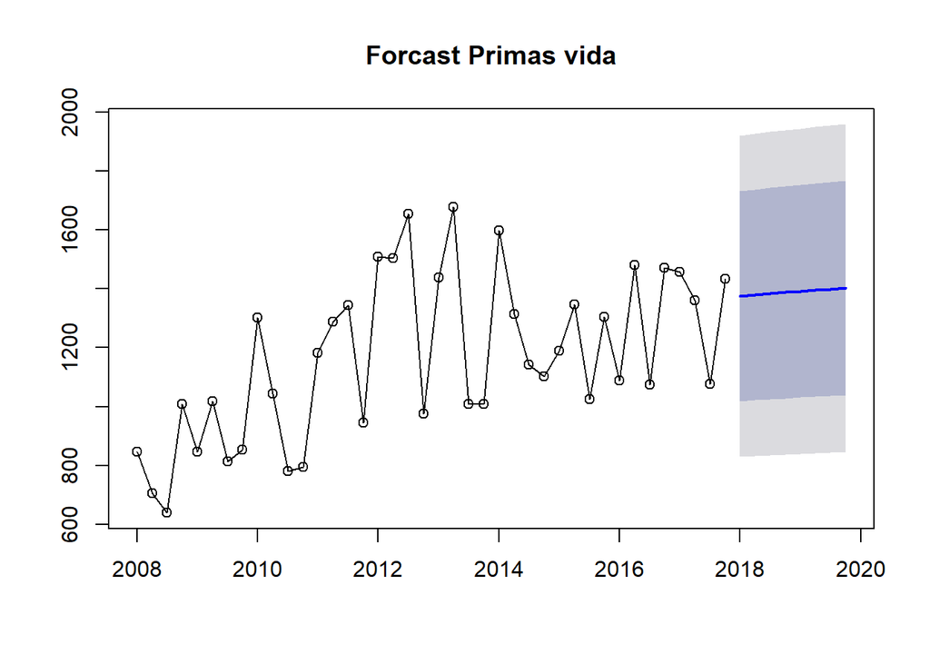

```r
## Eligio un MAM
## - M - multiplicativa la tendencia
## - A - aditiva en la pendiente
## - M - multiplicativa en estacionalidad

## ojo -> simpre que se hagan predicciones se debe dar un intervalo de confianza

# Plot
plot(vida.ets, main = "Forcast Primas vida")
lines(window(vida),type = "o")
```

## Modelo ETS para primas no vida

### Preparando datos

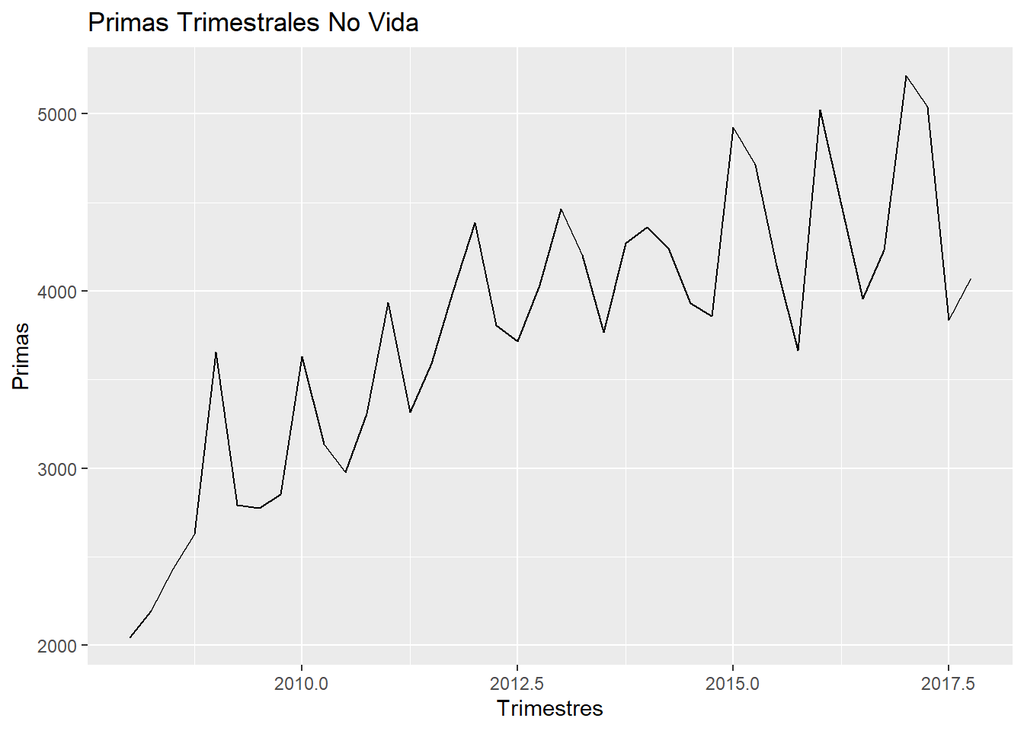

```r
## Plot Serie Primas No Vida
no_vida <- xts((datos$Primas_no_vida), order.by = datos$Fecha, frequency = 4)
## Generate quarterly data
no_vida <- to.quarterly(no_vida)  ## OJO cambia a que sea trimestral
## paqueteria zoo para mejor funcionamiento
no_vida <- as.zoo(no_vida$no_vida.Close)
autoplot(no_vida) + ggtitle("Primas Trimestrales No Vida") + xlab("Trimestres") + ylab("Primas")
```

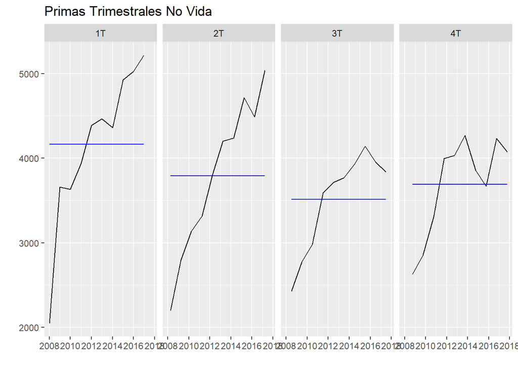

```r
## Seasonal Plot
ggfreqplot(as.ts(no_vida), freq = 4, nrow = 1, facet.labeller = c("1T","2T","3T","4T")) +
  ggtitle("Primas Trimestrales No Vida")
```

### Trainig set

```r
#- Training set     -#-#-#-#-#-#-#-#-#-#-#-#-#-#-#-#-#-#-#-#-#-#-#-#-#-#-#-#-#-#-#-#-#-#-#-#-#-#-#-#

## Select number of observation to compare forecast
cOmit = 4

## Data Size
nObs = length(no_vida)

## sub_sample
ono_vida <- window(no_vida,start = index(no_vida[1]),end = index(no_vida[nObs - cOmit]))
```

### Test

```r
no_vidaetsfit <- ets(ono_vida)
#f orecast model
fno_vida.ets = forecast(no_vidaetsfit)
# Results
summary(fno_vida.ets)
```

```
##
## Forecast method: ETS(A,Ad,A)
##
## Model Information:
## ETS(A,Ad,A)
##
## Call:
##  ets(y = ono_vida)
##
##   Smoothing parameters:
##     alpha = 1e-04
##     beta  = 1e-04
##     gamma = 1e-04
##     phi   = 0.9528
##
##   Initial states:
##     l = 2198.3617
##     b = 139.3579
##     s = -177.7518 -262.1253 -31.6318 471.5088
##
##   sigma:  281.2049
##
##      AIC     AICc      BIC
## 544.6642 553.4642 560.4993
##
## Error measures:
##                     ME     RMSE      MAE        MPE     MAPE      MASE
## Training set -2.874209 243.5306 177.8518 -0.8179414 5.275064 0.5325852
##                    ACF1
## Training set 0.08366937
##
## Forecasts:
##         Point Forecast    Lo 80    Hi 80    Lo 95    Hi 95
## 2017 Q1       5011.332 4650.954 5371.711 4460.181 5562.484
## 2017 Q2       4530.372 4169.993 4890.751 3979.220 5081.524
## 2017 Q3       4320.964 3960.585 4681.343 3769.813 4872.116
## 2017 Q4       4425.462 4065.084 4785.841 3874.311 4976.614
## 2018 Q1       5093.817 4733.438 5454.196 4542.665 5644.969
## 2018 Q2       4608.960 4248.581 4969.339 4057.808 5160.112
## 2018 Q3       4395.839 4035.460 4756.218 3844.687 4946.991
## 2018 Q4       4496.800 4136.421 4857.179 3945.648 5047.952
```

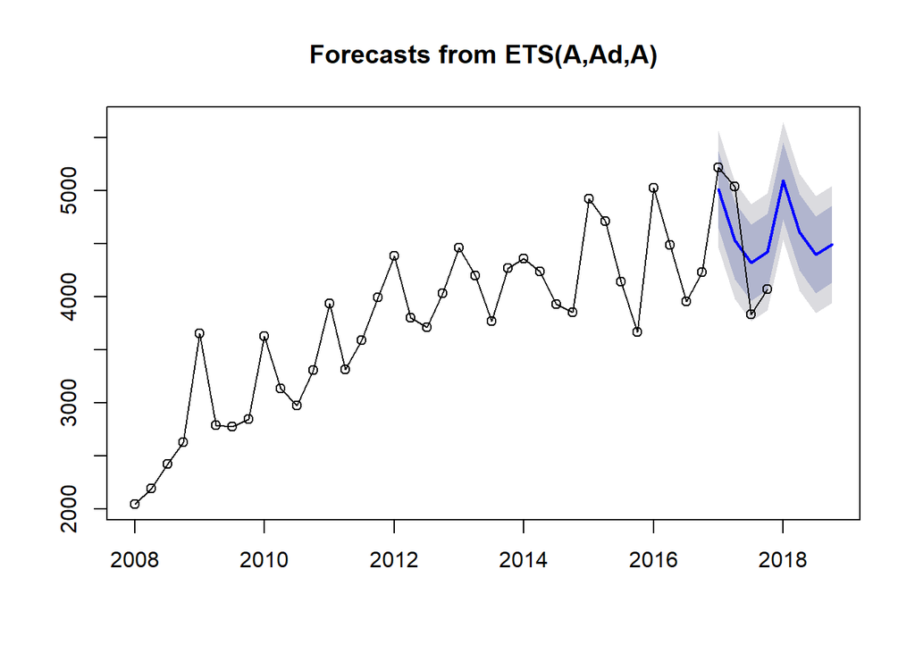

```r
## Eligio un MAM
## - M - multiplicativa la tendencia
## - A - aditiva en la pendiente
## - M - multiplicativa en estacionalidad

## ojo -> simpre que se hagan predicciones se debe dar un intervalo de confianza

# Plot
plot(fno_vida.ets)
lines(window(no_vida),type = "o")
```

### Métrica de predicción

```r
#Actual and Forecast
no_vidaFitmat <- matrix(c(fno_vida.ets$mean[1:cOmit],no_vida[(nObs - cOmit + 1):nObs]),ncol = 2)
no_vidaFitmat
```

```
##          [,1]   [,2]
## [1,] 5011.332 5217.9
## [2,] 4530.372 5038.2
## [3,] 4320.964 3837.7
## [4,] 4425.462 4073.8
```

```r
## MSE
mean((no_vidaFitmat[,1] - no_vidaFitmat[,2])^2)
```

```
## [1] 164442.5
```

```r
## MAE
mean(abs(no_vidaFitmat[,1] - no_vidaFitmat[,2]))
```

```
## [1] 387.3306
```

```r
## Bias
mean((no_vidaFitmat[,1] - no_vidaFitmat[,2]))
```

```
## [1] 30.13263
```

### Predicción

```r
#- Complete set        -#-#-#-#-#-#-#-#-#-#-#-#-#-#-#-#-#-#-#-#-#-#-#-#-#-#-#-#-#-#-#-#-#-#-#-#-#-#-#-#

## Select automatic ETS
etsfit <- ets(no_vida)
## forecast model
no_vida.ets <- forecast(etsfit)
## Results
summary(no_vida.ets)
```

```
##
## Forecast method: ETS(A,Ad,A)
##
## Model Information:
## ETS(A,Ad,A)
##
## Call:
##  ets(y = no_vida)
##
##   Smoothing parameters:
##     alpha = 4e-04
##     beta  = 1e-04
##     gamma = 2e-04
##     phi   = 0.9527
##
##   Initial states:
##     l = 2203.7506
##     b = 138.7075
##     s = -206.3655 -295.8864 16.1935 486.0584
##
##   sigma:  297.9073
##
##      AIC     AICc      BIC
## 613.1021 620.6883 629.9909
##
## Error measures:
##                     ME     RMSE      MAE        MPE     MAPE      MASE
## Training set -2.103476 262.2599 198.7776 -0.8237639 5.729095 0.6111534
##                    ACF1
## Training set 0.08167387
##
## Forecasts:
##         Point Forecast    Lo 80    Hi 80    Lo 95    Hi 95
## 2018 Q1       5099.550 4717.767 5481.334 4515.663 5683.438
## 2018 Q2       4647.861 4266.078 5029.645 4063.974 5231.749
## 2018 Q3       4352.951 3971.167 4734.735 3769.063 4936.839
## 2018 Q4       4458.972 4077.188 4840.756 3875.084 5042.860
## 2019 Q1       5166.934 4785.150 5548.718 4583.046 5750.822
## 2019 Q2       4712.056 4330.272 5093.840 4128.168 5295.945
## 2019 Q3       4414.108 4032.324 4795.892 3830.219 4997.996
## 2019 Q4       4517.235 4135.450 4899.019 3933.346 5101.123
```

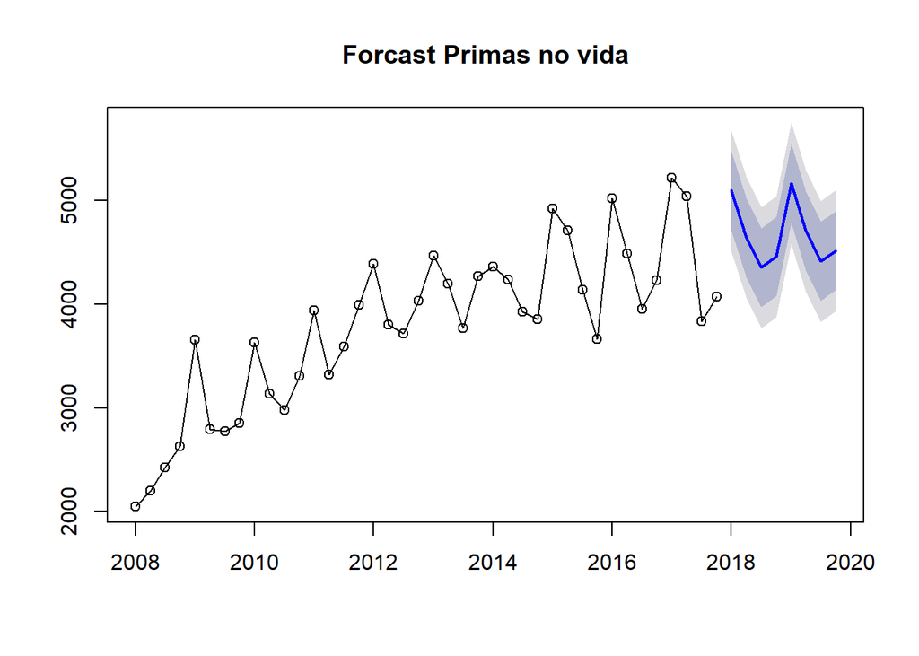

```r
## Eligio un MAM
## - M - multiplicativa la tendencia
## - A - aditiva en la pendiente
## - M - multiplicativa en estacionalidad

## ojo -> simpre que se hagan predicciones se debe dar un intervalo de confianza

# Plot
plot(no_vida.ets, main = "Forcast Primas no vida")
lines(window(no_vida),type = "o")
```

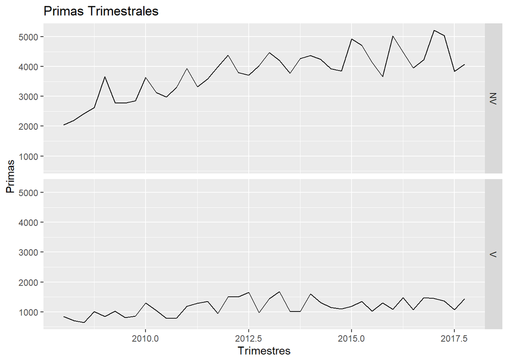

```r
## modelo ETS desde el enfoque de series de tiempo jerarquicas (hts)
##

## Plot Series
sepxts <- xts(datos[,c(3,4)], order.by = datos$Fecha, frequency = 4)
## Generate quarterly data
sepxtsVida   <- to.quarterly(sepxts$Primas_vida)     ## OJO cambia a que sea trimestral
sepxtsNoVida <- to.quarterly(sepxts$Primas_no_vida)  ## OJO cambia a que sea trimestral
## paqueteria zoo para mejor funcionamiento
sepxts <- cbind(sepxtsNoVida$`sepxts$Primas_no_vida.Close`, sepxtsVida$`sepxts$Primas_vida.Close`)
sepxts <- as.zoo(sepxts)
names(sepxts) <- c("NV", "V")
autoplot(sepxts) + ggtitle("Primas Trimestrales") + xlab("Trimestres") + ylab("Primas")
```

```r
## Select automatic HTS
sepmod <- hts(sepxts, nodes = list(2))
```

```
## Since argument characters are not specified, the default labelling system is used.
```

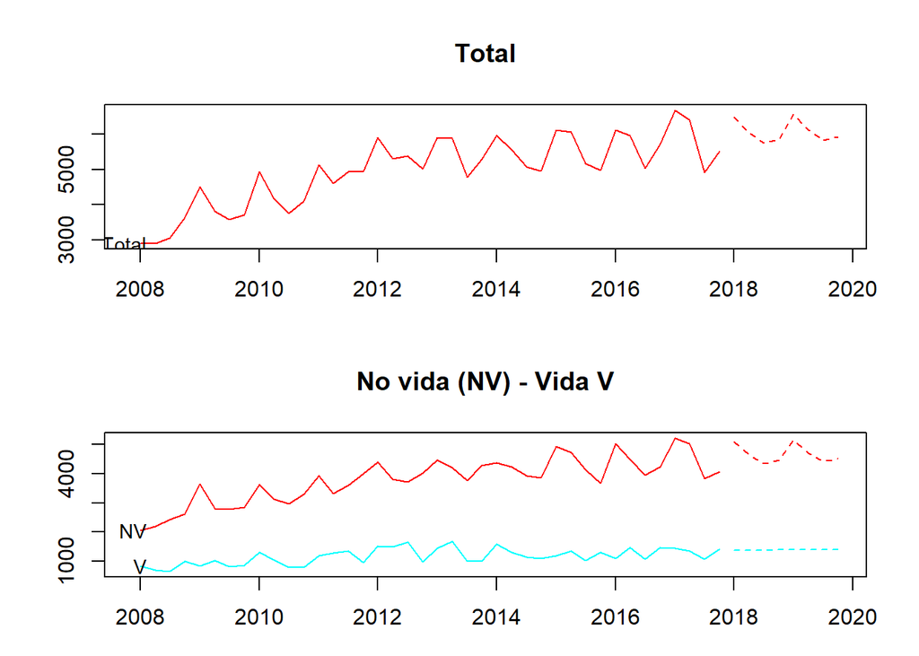

```r
## Forcast
sep.fit <- forecast(sepmod, method = 'bu', fmethod = 'ets') # buttom up
names(sep.fit$labels) = c("Total", "No vida (NV) - Vida V")
plot(sep.fit)
```

## Suma de vida y no vida ETS

```r
## Despues de trabajar por separado vida y no vida sumamos para ver la prediccion total

#Actual and Forecast
sumaFitmat <- vidaFitmat + no_vidaFitmat
sumaFitmat
```

```
##          [,1]   [,2]
## [1,] 6295.395 6674.6
## [2,] 5814.435 6398.6
## [3,] 5605.027 4913.4
## [4,] 5709.525 5507.2
```

```r
## MSE
mean((sumaFitmat[,1] - sumaFitmat[,2])^2)
```

```
## [1] 251082.2
```

```r
## MAE
mean(abs(sumaFitmat[,1] - sumaFitmat[,2]))
```

```
## [1] 464.3306
```

```r
## Bias
mean(sumaFitmat[,1] - sumaFitmat[,2])
```

```
## [1] -17.35465
```

## Modelo ARIMA para primas totales

### Preparando datos y análisis por diferencias

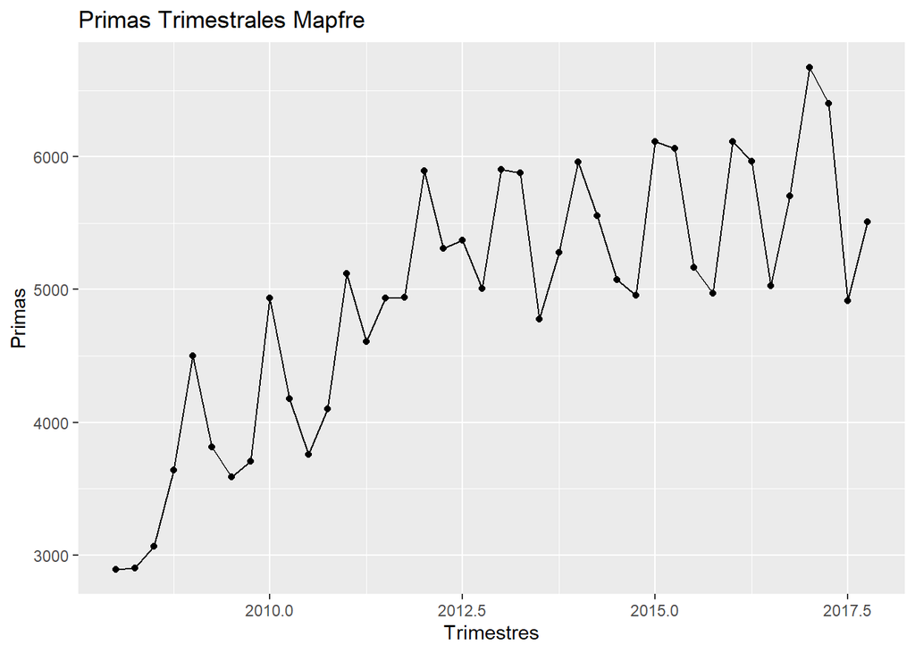

```r
## Nuestra ts de primas totales se llama "total"

df_total <- data.frame(value = as.vector(total),
                       time = time(total))
ggplot(df_total) + geom_point(aes(x = time, y = value)) +
  geom_line(aes(x = time, y = value)) +
  ylab("Primas") +
  ggtitle("Primas Trimestrales Mapfre") +
  xlab("Trimestres")
```

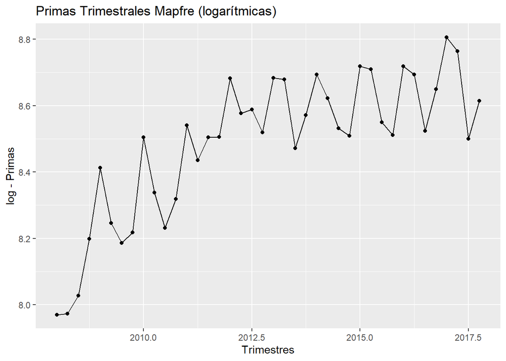

```r
## trabajamos con transformacion logaritmica
logTotal <- log(total)
df_logTotal <- data.frame(value = as.vector(logTotal),
                      time = time(logTotal))
ggplot(df_logTotal) + geom_point(aes(x = time, y = value)) +
  geom_line(aes(x = time, y = value)) +
  ylab("log - Primas") +
  ggtitle("Primas Trimestrales Mapfre (logarítmicas)") +
  xlab("Trimestres")
```

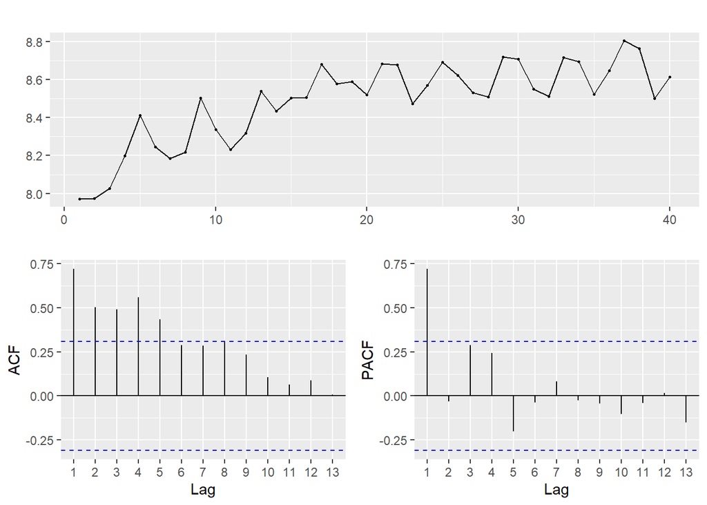

```r
## Difference
ggtsdisplay(logTotal)
```

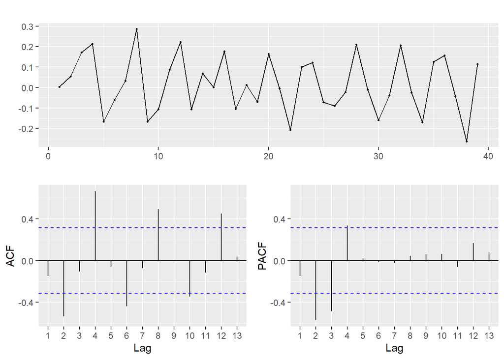

```r
ggtsdisplay(diff(logTotal))
```

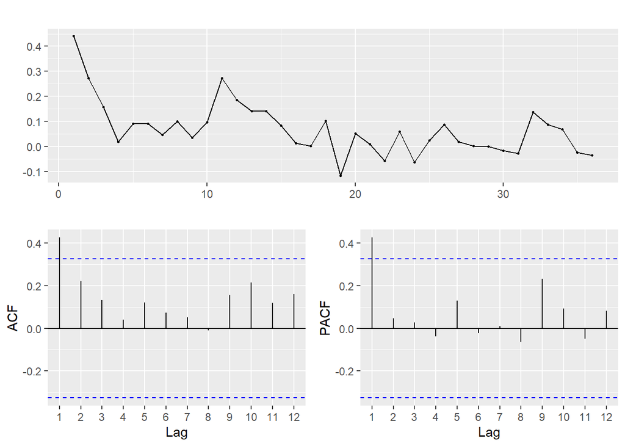

```r
ggtsdisplay(diff(logTotal,4))
```

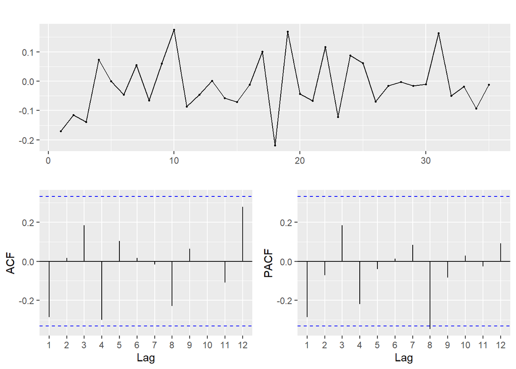

```r
ggtsdisplay(diff(diff(logTotal,4),1))
```